# TMDB电影数据分析项目

**作者：** 杨振彪 **日期：** 2025年08月01日

## 项目目标

1. 探索影响电影票房的关键因素（预算、类型、导演等）
2. 分析不同电影类型的盈利能力
3. 识别高投资回报率(ROI)的电影特征
4. 为电影投资决策提供数据支持

## 1. 数据加载与初探

```python
# 导入所需数据库
import numpy as np
import pandas as pd
import matplotlib.pyplot as plt
import seaborn as sns
import ast # 安全解析为python对象
from collections import Counter


# 设置图表样式
sns.set_style("whitegrid")
plt.rcParams['font.sans-serif'] = ['SimHei']  # 正常显示中文标签
plt.rcParams['axes.unicode_minus'] = False    # 正常显示负号

# 导入数据
movies_df = pd.read_csv("..\\data\\tmdb_5000_movies.csv")
credits_df = pd.read_csv("..\\data\\tmdb_5000_credits.csv")

print("电影数据集形状：",movies_df.shape)
print("演职员数据集形状：",credits_df.shape)
```

```
电影数据集形状： (4803, 20)
演职员数据集形状： (4803, 4)
```

```python
# 查看电影的数据前2行
print(movies_df.head(2))
print("*"*50)
# 查看电影数据基本信息
print(movies_df.info())
```

```
      budget                                             genres  \
0  237000000  [{"id": 28, "name": "Action"}, {"id": 12, "nam...
1  300000000  [{"id": 12, "name": "Adventure"}, {"id": 14, "...

                                       homepage     id  \
0                   http://www.avatarmovie.com/  19995
1  http://disney.go.com/disneypictures/pirates/    285

                                            keywords original_language  \
0  [{"id": 1463, "name": "culture clash"}, {"id":...                en
1  [{"id": 270, "name": "ocean"}, {"id": 726, "na...                en

                             original_title  \
0                                    Avatar
1  Pirates of the Caribbean: At World's End

                                            overview  popularity  \
0  In the 22nd century, a paraplegic Marine is di...  150.437577
1  Captain Barbossa, long believed to be dead, ha...  139.082615

                                production_companies  \
0  [{"name": "Ingenious Film Partners", "id": 289...
1  [{"name": "Walt Disney Pictures", "id": 2}, {"...

                                production_countries release_date     revenue  \
0  [{"iso_3166_1": "US", "name": "United States o...   2009-12-10  2787965087
1  [{"iso_3166_1": "US", "name": "United States o...   2007-05-19   961000000

   runtime                                   spoken_languages    status  \
0    162.0  [{"iso_639_1": "en", "name": "English"}, {"iso...  Released
1    169.0           [{"iso_639_1": "en", "name": "English"}]  Released

                                          tagline  \
0                     Enter the World of Pandora.
1  At the end of the world, the adventure begins.

                                      title  vote_average  vote_count
0                                    Avatar           7.2       11800
1  Pirates of the Caribbean: At World's End           6.9        4500
<class 'pandas.core.frame.DataFrame'>
```

[output cut: 12 more lines]

```
 8   popularity            4803 non-null   float64
 9   production_companies  4803 non-null   object
 10  production_countries  4803 non-null   object
 11  release_date          4802 non-null   object
 12  revenue               4803 non-null   int64
 13  runtime               4801 non-null   float64
 14  spoken_languages      4803 non-null   object
 15  status                4803 non-null   object
 16  tagline               3959 non-null   object
 17  title                 4803 non-null   object
 18  vote_average          4803 non-null   float64
 19  vote_count            4803 non-null   int64
dtypes: float64(3), int64(4), object(13)
memory usage: 750.6+ KB
None
```

```python
# 查看演职员的数据前2行
print(credits_df.head(2))
print("*"*50)
# 查看演职员数据基本信息
print(credits_df.info())
```

```
   movie_id                                     title  \
0     19995                                    Avatar
1       285  Pirates of the Caribbean: At World's End

                                                cast  \
0  [{"cast_id": 242, "character": "Jake Sully", "...
1  [{"cast_id": 4, "character": "Captain Jack Spa...

                                                crew
0  [{"credit_id": "52fe48009251416c750aca23", "de...
1  [{"credit_id": "52fe4232c3a36847f800b579", "de...
<class 'pandas.core.frame.DataFrame'>
RangeIndex: 4803 entries, 0 to 4802
Data columns (total 4 columns):
 #   Column    Non-Null Count  Dtype
---  ------    --------------  -----
 0   movie_id  4803 non-null   int64
 1   title     4803 non-null   object
 2   cast      4803 non-null   object
 3   crew      4803 non-null   object
dtypes: int64(1), object(3)
memory usage: 150.2+ KB
None
```

```python
# 数值型变量的描述性统计
movies_df[["budget","revenue","popularity","runtime","vote_average","vote_count"]].describe()
```

|  | budget | revenue | popularity | runtime | vote_average | vote_count |
| --- | --- | --- | --- | --- | --- | --- |
| count | 4.803000e+03 | 4.803000e+03 | 4803.000000 | 4801.000000 | 4803.000000 | 4803.000000 |
| mean | 2.904504e+07 | 8.226064e+07 | 21.492301 | 106.875859 | 6.092172 | 690.217989 |
| std | 4.072239e+07 | 1.628571e+08 | 31.816650 | 22.611935 | 1.194612 | 1234.585891 |
| min | 0.000000e+00 | 0.000000e+00 | 0.000000 | 0.000000 | 0.000000 | 0.000000 |
| 25% | 7.900000e+05 | 0.000000e+00 | 4.668070 | 94.000000 | 5.600000 | 54.000000 |
| 50% | 1.500000e+07 | 1.917000e+07 | 12.921594 | 103.000000 | 6.200000 | 235.000000 |
| 75% | 4.000000e+07 | 9.291719e+07 | 28.313505 | 118.000000 | 6.800000 | 737.000000 |
| max | 3.800000e+08 | 2.787965e+09 | 875.581305 | 338.000000 | 10.000000 | 13752.000000 |

**初步观察:**

- 数据集包含4803部电影的信息
- 预算(budget)和票房(revenue)中有大量0值，需要处理
- 部分字段(如genres)是JSON格式字符串，需要解析
- 平均评分为6.09分(满分10分)，投票数差异很大

## 2. 数据清洗与预处理

```python
# 合并数据
credits_df = credits_df[["movie_id","cast","crew"]]
movies_df = movies_df.merge(credits_df,left_on="id",right_on="movie_id")
print(movies_df.columns)
```

```
Index(['budget', 'genres', 'homepage', 'id', 'keywords', 'original_language',
       'original_title', 'overview', 'popularity', 'production_companies',
       'production_countries', 'release_date', 'revenue', 'runtime',
       'spoken_languages', 'status', 'tagline', 'title', 'vote_average',
       'vote_count', 'movie_id', 'cast', 'crew'],
      dtype='object')
```

```python
# 根据分析目标选择需要的列
key_columns = ["id","title","genres","keywords","release_date","runtime","budget","revenue","original_language","vote_average",
               "vote_count","cast","crew","overview","production_companies","production_countries","popularity"]
movies_df = movies_df[key_columns]
```

```python
# 处理缺失值
print("缺失值统计：")
print(movies_df.isnull().sum()) # 查看每列缺失值，根据重要程度进行修改/删除/忽略

# 填充runtime的缺失值
movies_df["runtime"] = movies_df["runtime"].fillna(movies_df["runtime"].median())
# 删除release_date缺失的行
movies_df = movies_df.dropna(subset=["release_date"])
```

```
缺失值统计：
id                      0
title                   0
genres                  0
keywords                0
release_date            1
runtime                 2
budget                  0
revenue                 0
original_language       0
vote_average            0
vote_count              0
cast                    0
crew                    0
overview                3
production_companies    0
production_countries    0
popularity              0
dtype: int64
```

```python
# 处理异常值 对不合理的数据修改，比如预算和票房为0的视为缺失值，小于1000视为无效数据
movies_df = movies_df[(movies_df["budget"]>1000) & (movies_df["revenue"]>1000)]
# movies_df = movies_df[movies_df["vote_count"] >= 0]
```

```python
# 修改日期数据类型，创建年月相关的列，方便按年分析
movies_df["release_date"] = pd.to_datetime(movies_df["release_date"]) # 讲日期转化为datetime类型
movies_df["release_year"] = movies_df["release_date"].dt.year # 提取上映年份，方便按年分析
movies_df["release_month"] = movies_df["release_date"].dt.month # 提取月份

# 计算盈利能力（profit），和投资回报率（ROI）
movies_df["profit"] = movies_df["revenue"] - movies_df["budget"]
movies_df["roi"] = (movies_df["profit"]/movies_df["budget"])*100 # 求百分比

# 处理RIO异常值
movies_df.loc[movies_df["budget"] <= 0,'roi'] = np.nan
movies_df["roi"] = movies_df["roi"].replace([np.inf,-np.inf] , np.nan)
```

```python
# 解析JSON格式列 (genres, keywords, cast, crew, production_companies, production_countries)
# 这些列存储的是字符串形式的JSON列表，需要解析成Python对象（列表/字典）
def parse_json_column(column):
    try:
        return ast.literal_eval(column)
    except (ValueError,SyntaxError):
        return [] # 失败返回空列表

json_columns = ["genres","keywords","cast","crew","production_companies","production_countries"]
for col in json_columns:
    movies_df[col] = movies_df[col].apply(parse_json_column)
```

```python
# 从crew列提取导演信息
def get_director(crew_list):
    for person in crew_list:
        if person["job"] == "Director":
            return person["name"]
    return np.nan

movies_df["director"] = movies_df["crew"].apply(get_director)

# 从 genres 列提取电影类型
def get_genres_list(genre_list):
    if isinstance(genre_list,list):
        return [genre["name"] for genre in genre_list]
    else:
        return []

movies_df["genres_list"] = movies_df["genres"].apply(get_genres_list)
```

```python
# 查看处理后的数据
print("清洗后数据集形状：",movies_df.shape)
movies_df[["title","release_year","budget","revenue","profit","roi","genres_list","director"]].head(3)
```

```
清洗后数据集形状： (3211, 23)
```

|  | title | release_year | budget | revenue | profit | roi | genres_list | director |
| --- | --- | --- | --- | --- | --- | --- | --- | --- |
| 0 | Avatar | 2009 | 237000000 | 2787965087 | 2550965087 | 1076.356577 | [Action, Adventure, Fantasy, Science Fiction] | James Cameron |
| 1 | Pirates of the Caribbean: At World's End | 2007 | 300000000 | 961000000 | 661000000 | 220.333333 | [Adventure, Fantasy, Action] | Gore Verbinski |
| 2 | Spectre | 2015 | 245000000 | 880674609 | 635674609 | 259.459024 | [Action, Adventure, Crime] | Sam Mendes |

## 3. 探索性数据分析（EDA）

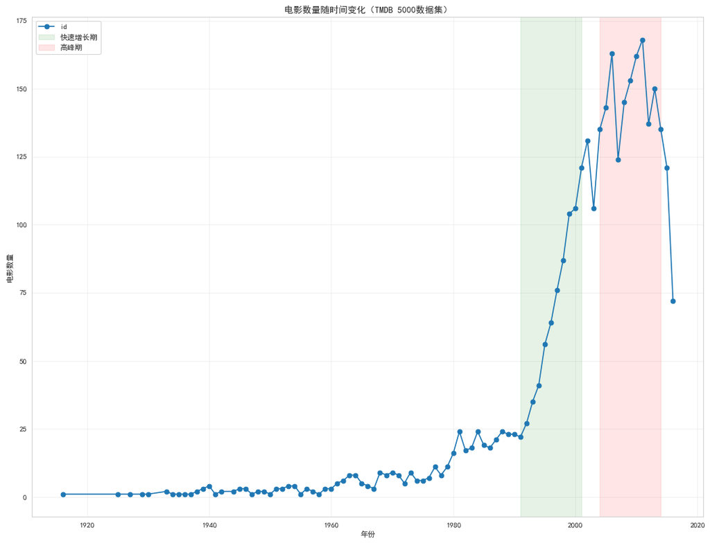

```python
# 电影数量按年变化
plt.figure(figsize=(16,12),dpi=80)
movies_per_year = movies_df.groupby('release_year')['id'].count()
movies_per_year.plot(kind='line',marker='o')
plt.title("电影数量随时间变化（TMDB 5000数据集）")
plt.xlabel("年份")
plt.ylabel("电影数量")
plt.grid(True,alpha=0.3)
plt.axvspan(1991,2001,color='green',alpha=0.1,label='快速增长期')
plt.axvspan(2004,2014,color='red',alpha=0.1,label='高峰期')
plt.legend()
plt.show()
```

**电影数量分析:**

- 由图可知1960年以前电影数量多为个位数，可以考虑从1960年开始分析

```python
# 修改电影数据
movies_df = movies_df[movies_df['release_year'] >= 1960]
# 查看处理后数据
print("1960年后电影数据集形状：",movies_df.shape)
```

```
1960年后电影数据集形状： (3150, 23)
```

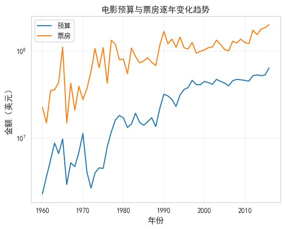

```python
# 预算和票房随年份的变化，取中位数减少异常值判断
plt.figure(figsize=(16,12),dpi=80)
movies_df.groupby("release_year")[["budget","revenue"]].mean().plot(kind='line')
plt.title("电影预算与票房逐年变化趋势")
plt.xlabel("年份",fontsize=12)
plt.ylabel("金额（美元）",fontsize=12)
plt.legend(["预算","票房"])
plt.yscale('log') # 对数坐标轴，更清晰的显示变化
plt.grid(True,alpha=0.3)
plt.show()
```

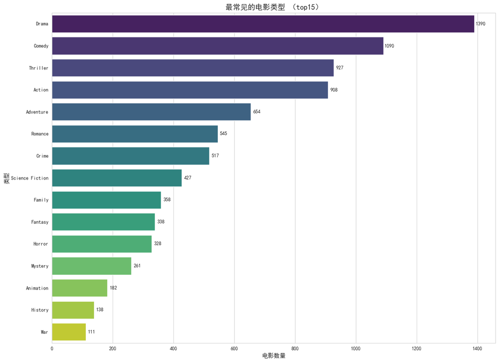

```python
# 电影类型分析
# 创建一个包含所有类型的列表并统计频率
all_genres = []
for genres in movies_df["genres_list"]:
    all_genres.extend(genres)

# 分析那类电影更受欢迎
plt.figure(figsize=(16,12))
top_genres = pd.Series(all_genres).value_counts().head(15)
genres_bar = sns.barplot(x=top_genres.values , y=top_genres.index ,hue=top_genres.index , palette='viridis',legend=False)
plt.title("最常见的电影类型 （top15）",fontsize=15)
plt.xlabel("电影数量",fontsize=12)
plt.ylabel("类型",fontsize=12)
# 在每个条形的末端显示电影数量
for i in genres_bar.patches:
    # 计算数值的位置
    width = i.get_width()
    # 在条形末端附近显示数值
    plt.text(width + 20, # 距离条形末端稍微向右一点
             i.get_y() + i.get_height()/2, # 居中对齐
             int(width), # 显示的数值
             ha='center', va='center')
plt.show()
```

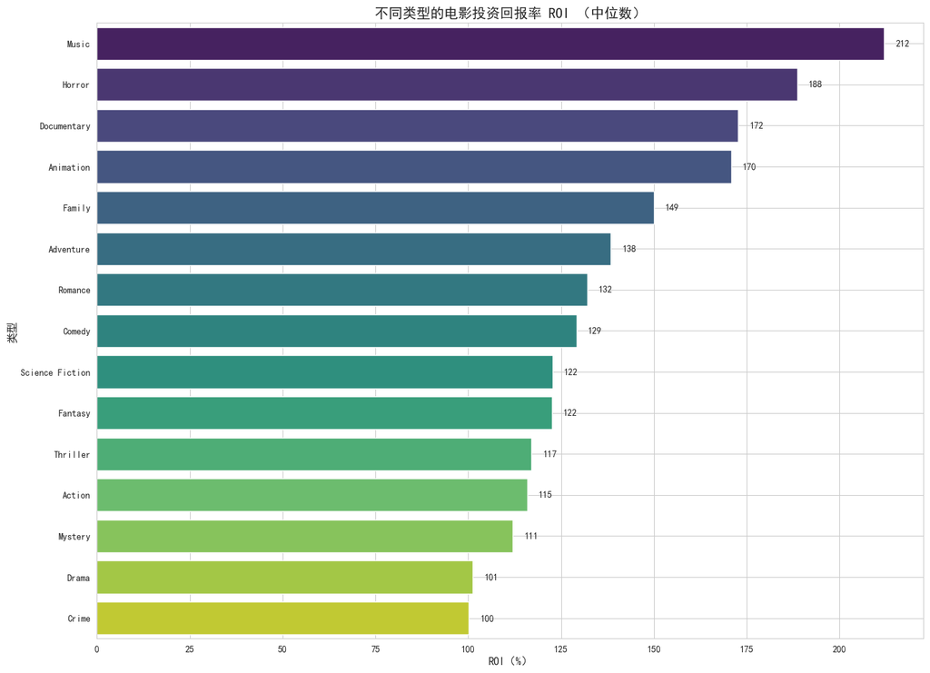

```python
# 分析每种类型的roi中位数，判断类型与盈利关系，需要先通过explode 方法将类型列表拆分为多行
genre_roi = movies_df.explode('genres_list').groupby('genres_list')['roi'].median().sort_values(ascending=False).dropna().head(15)

plt.figure(figsize=(16,12))
genres_roi_bar = sns.barplot(x=genre_roi.values , y=genre_roi.index ,hue=genre_roi.index , palette='viridis',legend=False)
plt.title("不同类型的电影投资回报率 ROI （中位数）",fontsize=15)
plt.xlabel("ROI（%）",fontsize=12)
plt.ylabel("类型",fontsize=12)
plt.grid(axis='y')
# 在每个条形的末端显示电影数量
for i in genres_roi_bar.patches:
    # 计算数值的位置
    width = i.get_width()
    # 在条形末端附近显示数值
    plt.text(width + 5, # 距离条形末端稍微向右一点
             i.get_y() + i.get_height()/2, # 居中对齐
             int(width), # 显示的数值
             ha='center', va='center')
plt.show()
```

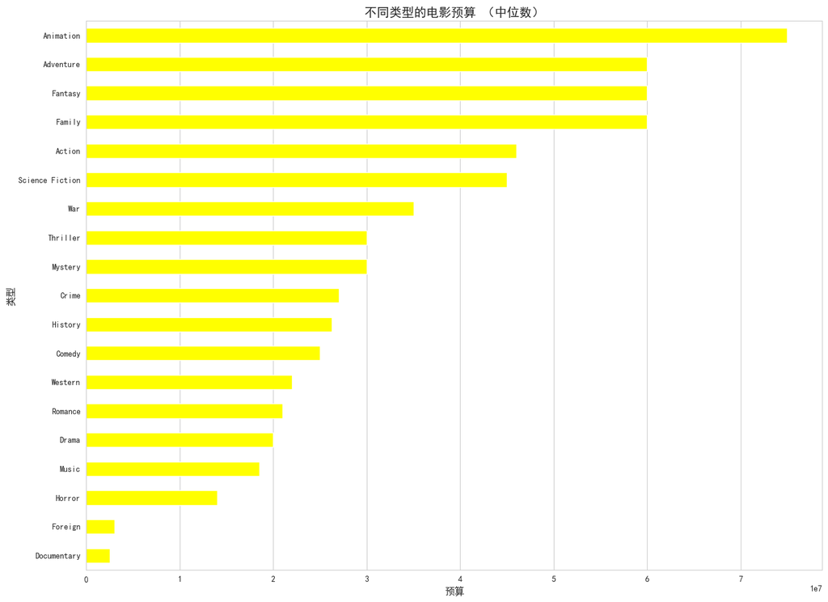

```python
# 分析每种类型的budget中位数，判断哪些是低成本电影
genre_budget = movies_df.explode('genres_list').groupby('genres_list')['budget'].median().sort_values().dropna()

plt.figure(figsize=(16,12))
genre_budget.plot(kind='barh',color='yellow')
plt.title("不同类型的电影预算 （中位数）",fontsize=15)
plt.xlabel("预算",fontsize=12)
plt.ylabel("类型",fontsize=12)
plt.grid(axis='y')
plt.show()
```

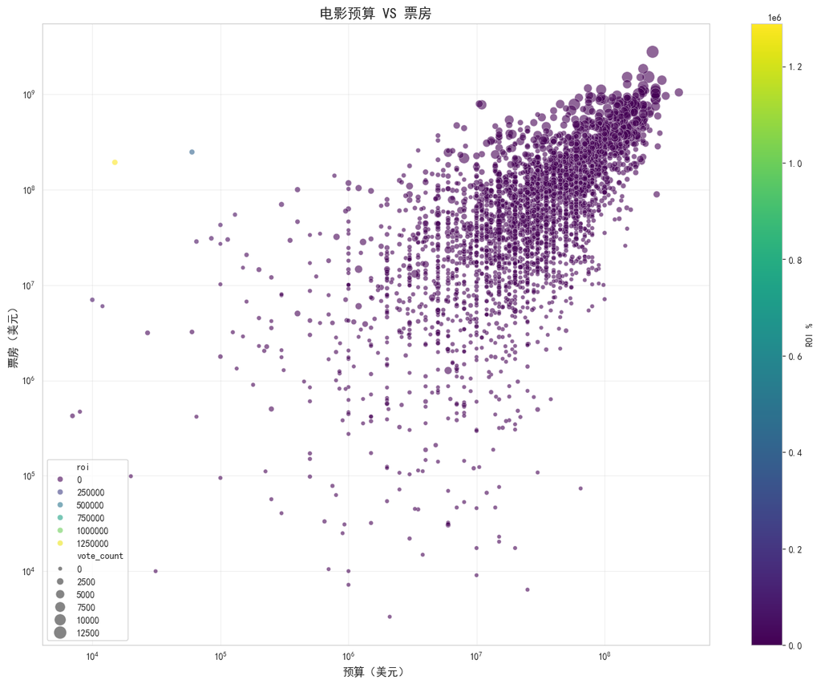

```python
# 预算与票房关系（散点图）
plt.figure(figsize=(16,12))
ax = sns.scatterplot(x="budget",y="revenue",data=movies_df,alpha=0.6,hue='roi',palette='viridis',size='vote_count',sizes=(20,200))
ax.set_title("电影预算 VS 票房",fontsize=15)
ax.set_xlabel("预算（美元）",fontsize=12)
ax.set_ylabel("票房（美元）",fontsize=12)
ax.set_xscale('log')
ax.set_yscale('log')
ax.grid(True,alpha=0.3)
# 获取当前的颜色映射对象
norm = plt.Normalize(movies_df['roi'].min(), movies_df['roi'].max())
sm = plt.cm.ScalarMappable(cmap="viridis", norm=norm)
sm.set_array([])
plt.colorbar(sm,label='ROI %',ax=ax) # 如果hue=roi生效
plt.show()
```

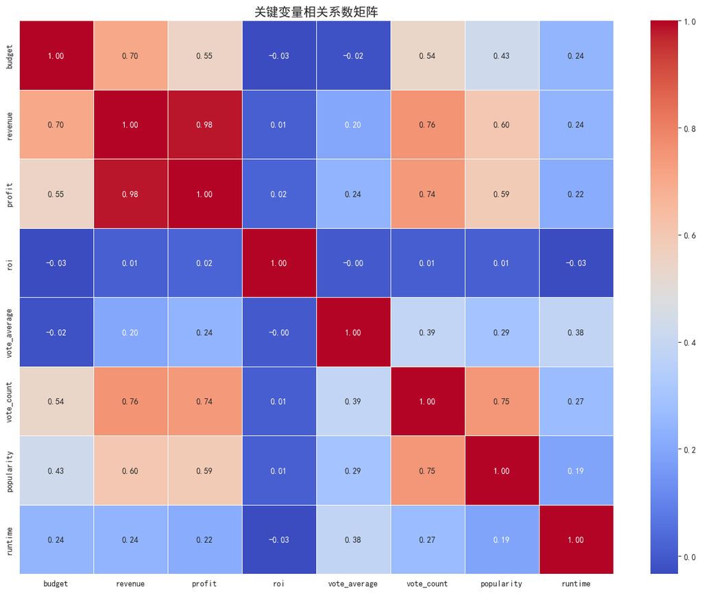

```python
# 相关系数热力图
corr_matrix = movies_df[["budget","revenue","profit","roi","vote_average","vote_count","popularity","runtime"]].corr()
plt.figure(figsize=(16,12))
sns.heatmap(corr_matrix,annot=True,cmap='coolwarm',fmt='.2f',linewidths=0.5)
plt.title("关键变量相关系数矩阵",fontsize=15)
plt.show()
```

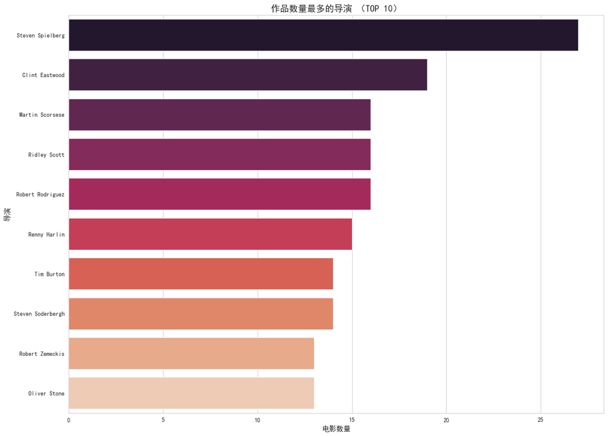

```python
# 导演分析 - 作品数量
top_directors = movies_df["director"].value_counts().head(10)
plt.figure(figsize=(16,12))
sns.barplot(x=top_directors.values,y=top_directors.index,hue=top_directors.index,palette='rocket')
plt.title("作品数量最多的导演 （TOP 10）",fontsize=15)
plt.xlabel("电影数量",fontsize=12)
plt.ylabel("导演",fontsize=12)
plt.show()
```

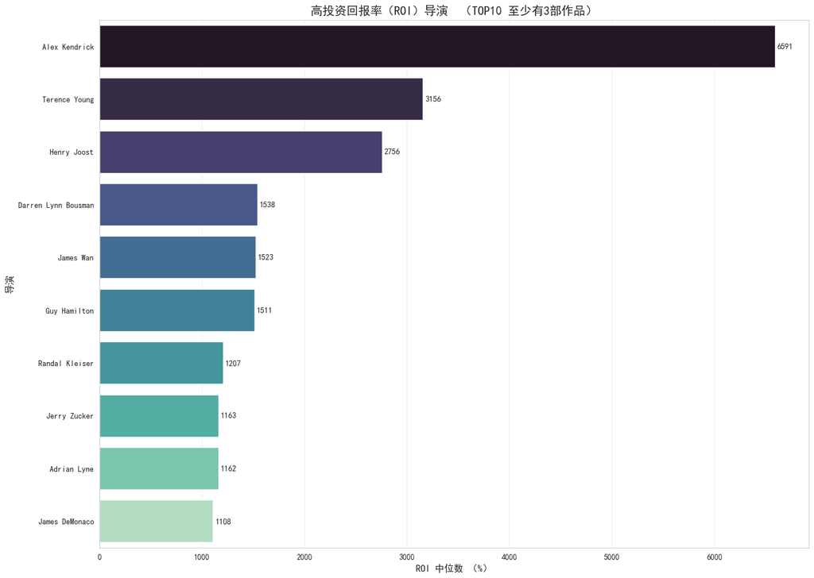

```
                 director  movie_count
28          Alex Kendrick            3
1286        Terence Young            4
483           Henry Joost            3
263   Darren Lynn Bousman            3
533             James Wan            6
466          Guy Hamilton            5
1050       Randal Kleiser            3
573          Jerry Zucker            4
6             Adrian Lyne            4
520        James DeMonaco            3
```

```python
# 导演分析 - ROI表现，导演至少导演3部作品
directors_stats = movies_df.groupby("director").agg(
    movie_count=('id','count'),
    median_roi=('roi','median'),
    median_revenue=('revenue','median'),
    median_budget=('budget','median')
).reset_index()
# 筛选至少有3部电影的导演
directors_stats = directors_stats[directors_stats['movie_count']  >= 3]
# 找到高回报率导演 （按中位数）
top_directors_roi = directors_stats.sort_values('median_roi',ascending=False).head(10)
plt.figure(figsize=(16,12))
director_roi_bar = sns.barplot(data=top_directors_roi,x='median_roi',y='director',hue='director',palette='mako')
plt.title("高投资回报率（ROI）导演  （TOP10 至少有3部作品）",fontsize=15)
plt.xlabel("ROI 中位数 （%）",fontsize=12)
plt.ylabel("导演",fontsize=12)
plt.grid(axis='x',alpha=0.3)
# 在每个条形的末端显示电影数量
for i in director_roi_bar.patches:
    # 计算数值的位置
    width = i.get_width()
    # 在条形末端附近显示数值
    plt.text(width + 100, # 距离条形末端稍微向右一点
             i.get_y() + i.get_height()/2, # 居中对齐
             int(width), # 显示的数值
             ha='center', va='center')
plt.show()
print(top_directors_roi[['director','movie_count']])
```

## 4. 分析结论与业务建议

### 项目总结

本分析揭示了电影投资的三个核心规律：

## 5. 技术总结

**技术栈:**

- Python数据分析: Pandas, NumPy
- 数据可视化: Matplotlib, Seaborn
- 数据清洗: 缺失值处理、异常值检测、JSON解析
- 特征工程: ROI计算、时间特征提取、文本解析

**关键技能:**

**数据局限性:**

- 数据集仅包含TMDB收录电影(偏重英语电影)
- 独立电影和小众电影代表不足
- 部分早期电影数据不完整

## 附录：关键代码片段

```python
# 解析JSON列的通用函数
def parse_json_column(column):
    try:
        return ast.literal_eval(column)
    except (ValueError,SyntaxError):
        return [] # 失败返回空列表
```

```python
# 提取电影类型的函数
def get_genres_list(genre_list):
    if isinstance(genre_list,list):
        return [genre["name"] for genre in genre_list]
    else:
        return []
```

```python
# 计算ROI并处理异常值
# 计算盈利能力（profit），和投资回报率（ROI）
movies_df["profit"] = movies_df["revenue"] - movies_df["budget"]
movies_df["roi"] = (movies_df["profit"]/movies_df["budget"])*100 # 求百分比

# 处理RIO异常值
movies_df.loc[movies_df["budget"] <= 0,'roi'] = np.nan
movies_df["roi"] = movies_df["roi"].replace([np.inf,-np.inf] , np.nan)
```